# Risk Factor Analysis

## Outcome Variable

**Outcome Variable:** ever_wasted

## Predictor Variables

**Intervention Variable:** mage

**Adjustment Set:**

- arm
- meducyrs
- feducyrs
- W_mhtcm
- W_mwtkg
- W_mbmi
- single
- delta_meducyrs
- delta_feducyrs
- delta_W_mhtcm
- delta_W_mwtkg
- delta_W_mbmi
- delta_single

## Stratifying Variables

The analysis was stratified on these variable(s):

- agecat
- studyid
- country

## Data Summary

| agecat | studyid | country | mage | ever_wasted | n_cell | n |
| --- | --- | --- | --- | --- | --- | --- |
| 0-24 months | CMC-V-BCS-2002 | INDIA | [20-30) | 0 | 118 | 373 |
| 0-24 months | CMC-V-BCS-2002 | INDIA | [20-30) | 1 | 178 | 373 |
| 0-24 months | CMC-V-BCS-2002 | INDIA | <20 | 0 | 9 | 373 |
| 0-24 months | CMC-V-BCS-2002 | INDIA | <20 | 1 | 25 | 373 |
| 0-24 months | CMC-V-BCS-2002 | INDIA | >=30 | 0 | 18 | 373 |
| 0-24 months | CMC-V-BCS-2002 | INDIA | >=30 | 1 | 25 | 373 |
| 0-24 months | COHORTS | GUATEMALA | [20-30) | 0 | 492 | 1341 |
| 0-24 months | COHORTS | GUATEMALA | [20-30) | 1 | 163 | 1341 |
| 0-24 months | COHORTS | GUATEMALA | <20 | 0 | 146 | 1341 |
| 0-24 months | COHORTS | GUATEMALA | <20 | 1 | 50 | 1341 |
| 0-24 months | COHORTS | GUATEMALA | >=30 | 0 | 361 | 1341 |
| 0-24 months | COHORTS | GUATEMALA | >=30 | 1 | 129 | 1341 |
| 0-24 months | COHORTS | INDIA | [20-30) | 0 | 2449 | 5305 |
| 0-24 months | COHORTS | INDIA | [20-30) | 1 | 1148 | 5305 |
| 0-24 months | COHORTS | INDIA | <20 | 0 | 274 | 5305 |
| 0-24 months | COHORTS | INDIA | <20 | 1 | 152 | 5305 |
| 0-24 months | COHORTS | INDIA | >=30 | 0 | 800 | 5305 |
| 0-24 months | COHORTS | INDIA | >=30 | 1 | 482 | 5305 |
| 0-24 months | COHORTS | PHILIPPINES | [20-30) | 0 | 1106 | 3045 |
| 0-24 months | COHORTS | PHILIPPINES | [20-30) | 1 | 714 | 3045 |
| 0-24 months | COHORTS | PHILIPPINES | <20 | 0 | 208 | 3045 |
| 0-24 months | COHORTS | PHILIPPINES | <20 | 1 | 169 | 3045 |
| 0-24 months | COHORTS | PHILIPPINES | >=30 | 0 | 502 | 3045 |
| 0-24 months | COHORTS | PHILIPPINES | >=30 | 1 | 346 | 3045 |
| 0-24 months | EE | PAKISTAN | [20-30) | 0 | 73 | 377 |
| 0-24 months | EE | PAKISTAN | [20-30) | 1 | 89 | 377 |
| 0-24 months | EE | PAKISTAN | <20 | 0 | 0 | 377 |
| 0-24 months | EE | PAKISTAN | <20 | 1 | 1 | 377 |
| 0-24 months | EE | PAKISTAN | >=30 | 0 | 81 | 377 |
| 0-24 months | EE | PAKISTAN | >=30 | 1 | 133 | 377 |

[output cut: 450 more lines]

The following strata were considered:

- agecat: 0-24 months, studyid: CMC-V-BCS-2002, country: INDIA
- agecat: 0-24 months, studyid: COHORTS, country: GUATEMALA
- agecat: 0-24 months, studyid: COHORTS, country: INDIA
- agecat: 0-24 months, studyid: COHORTS, country: PHILIPPINES
- agecat: 0-24 months, studyid: EE, country: PAKISTAN
- agecat: 0-24 months, studyid: GMS-Nepal, country: NEPAL
- agecat: 0-24 months, studyid: Guatemala BSC, country: GUATEMALA
- agecat: 0-24 months, studyid: iLiNS-Zinc, country: BURKINA FASO
- agecat: 0-24 months, studyid: IRC, country: INDIA
- agecat: 0-24 months, studyid: JiVitA-3, country: BANGLADESH
- agecat: 0-24 months, studyid: Keneba, country: GAMBIA
- agecat: 0-24 months, studyid: LCNI-5, country: MALAWI
- agecat: 0-24 months, studyid: MAL-ED, country: BANGLADESH
- agecat: 0-24 months, studyid: MAL-ED, country: BRAZIL
- agecat: 0-24 months, studyid: MAL-ED, country: INDIA
- agecat: 0-24 months, studyid: MAL-ED, country: NEPAL
- agecat: 0-24 months, studyid: MAL-ED, country: PERU
- agecat: 0-24 months, studyid: MAL-ED, country: SOUTH AFRICA
- agecat: 0-24 months, studyid: MAL-ED, country: TANZANIA, UNITED REPUBLIC OF
- agecat: 0-24 months, studyid: NIH-Birth, country: BANGLADESH
- agecat: 0-24 months, studyid: NIH-Crypto, country: BANGLADESH
- agecat: 0-24 months, studyid: PROBIT, country: BELARUS
- agecat: 0-24 months, studyid: PROVIDE, country: BANGLADESH
- agecat: 0-24 months, studyid: SAS-CompFeed, country: INDIA
- agecat: 0-24 months, studyid: SAS-FoodSuppl, country: INDIA
- agecat: 0-24 months, studyid: TanzaniaChild2, country: TANZANIA, UNITED REPUBLIC OF
- agecat: 0-24 months, studyid: ZVITAMBO, country: ZIMBABWE
- agecat: 0-6 months, studyid: CMC-V-BCS-2002, country: INDIA
- agecat: 0-6 months, studyid: COHORTS, country: GUATEMALA
- agecat: 0-6 months, studyid: COHORTS, country: INDIA
- agecat: 0-6 months, studyid: COHORTS, country: PHILIPPINES
- agecat: 0-6 months, studyid: EE, country: PAKISTAN
- agecat: 0-6 months, studyid: GMS-Nepal, country: NEPAL
- agecat: 0-6 months, studyid: Guatemala BSC, country: GUATEMALA
- agecat: 0-6 months, studyid: IRC, country: INDIA
- agecat: 0-6 months, studyid: JiVitA-3, country: BANGLADESH
- agecat: 0-6 months, studyid: Keneba, country: GAMBIA
- agecat: 0-6 months, studyid: LCNI-5, country: MALAWI
- agecat: 0-6 months, studyid: MAL-ED, country: BANGLADESH
- agecat: 0-6 months, studyid: MAL-ED, country: BRAZIL
- agecat: 0-6 months, studyid: MAL-ED, country: INDIA
- agecat: 0-6 months, studyid: MAL-ED, country: NEPAL
- agecat: 0-6 months, studyid: MAL-ED, country: PERU
- agecat: 0-6 months, studyid: MAL-ED, country: SOUTH AFRICA
- agecat: 0-6 months, studyid: MAL-ED, country: TANZANIA, UNITED REPUBLIC OF
- agecat: 0-6 months, studyid: NIH-Birth, country: BANGLADESH
- agecat: 0-6 months, studyid: NIH-Crypto, country: BANGLADESH
- agecat: 0-6 months, studyid: PROBIT, country: BELARUS
- agecat: 0-6 months, studyid: PROVIDE, country: BANGLADESH
- agecat: 0-6 months, studyid: SAS-CompFeed, country: INDIA
- agecat: 0-6 months, studyid: SAS-FoodSuppl, country: INDIA
- agecat: 0-6 months, studyid: TanzaniaChild2, country: TANZANIA, UNITED REPUBLIC OF
- agecat: 0-6 months, studyid: ZVITAMBO, country: ZIMBABWE
- agecat: 6-24 months, studyid: CMC-V-BCS-2002, country: INDIA
- agecat: 6-24 months, studyid: COHORTS, country: GUATEMALA
- agecat: 6-24 months, studyid: COHORTS, country: INDIA
- agecat: 6-24 months, studyid: COHORTS, country: PHILIPPINES
- agecat: 6-24 months, studyid: EE, country: PAKISTAN
- agecat: 6-24 months, studyid: GMS-Nepal, country: NEPAL
- agecat: 6-24 months, studyid: Guatemala BSC, country: GUATEMALA
- agecat: 6-24 months, studyid: iLiNS-Zinc, country: BURKINA FASO
- agecat: 6-24 months, studyid: IRC, country: INDIA
- agecat: 6-24 months, studyid: JiVitA-3, country: BANGLADESH
- agecat: 6-24 months, studyid: Keneba, country: GAMBIA
- agecat: 6-24 months, studyid: LCNI-5, country: MALAWI
- agecat: 6-24 months, studyid: MAL-ED, country: BANGLADESH
- agecat: 6-24 months, studyid: MAL-ED, country: BRAZIL
- agecat: 6-24 months, studyid: MAL-ED, country: INDIA
- agecat: 6-24 months, studyid: MAL-ED, country: NEPAL
- agecat: 6-24 months, studyid: MAL-ED, country: PERU
- agecat: 6-24 months, studyid: MAL-ED, country: SOUTH AFRICA
- agecat: 6-24 months, studyid: MAL-ED, country: TANZANIA, UNITED REPUBLIC OF
- agecat: 6-24 months, studyid: NIH-Birth, country: BANGLADESH
- agecat: 6-24 months, studyid: NIH-Crypto, country: BANGLADESH
- agecat: 6-24 months, studyid: PROBIT, country: BELARUS
- agecat: 6-24 months, studyid: PROVIDE, country: BANGLADESH
- agecat: 6-24 months, studyid: SAS-CompFeed, country: INDIA
- agecat: 6-24 months, studyid: SAS-FoodSuppl, country: INDIA
- agecat: 6-24 months, studyid: TanzaniaChild2, country: TANZANIA, UNITED REPUBLIC OF
- agecat: 6-24 months, studyid: ZVITAMBO, country: ZIMBABWE

### Dropped Strata

Some strata were dropped due to rare outcomes:

- agecat: 0-24 months, studyid: EE, country: PAKISTAN
- agecat: 0-24 months, studyid: MAL-ED, country: BRAZIL
- agecat: 0-24 months, studyid: MAL-ED, country: NEPAL
- agecat: 0-24 months, studyid: MAL-ED, country: TANZANIA, UNITED REPUBLIC OF
- agecat: 0-6 months, studyid: EE, country: PAKISTAN
- agecat: 0-6 months, studyid: Guatemala BSC, country: GUATEMALA
- agecat: 0-6 months, studyid: LCNI-5, country: MALAWI
- agecat: 0-6 months, studyid: MAL-ED, country: BRAZIL
- agecat: 0-6 months, studyid: MAL-ED, country: INDIA
- agecat: 0-6 months, studyid: MAL-ED, country: NEPAL
- agecat: 0-6 months, studyid: MAL-ED, country: PERU
- agecat: 0-6 months, studyid: MAL-ED, country: TANZANIA, UNITED REPUBLIC OF
- agecat: 6-24 months, studyid: EE, country: PAKISTAN
- agecat: 6-24 months, studyid: Guatemala BSC, country: GUATEMALA
- agecat: 6-24 months, studyid: MAL-ED, country: BRAZIL
- agecat: 6-24 months, studyid: MAL-ED, country: INDIA
- agecat: 6-24 months, studyid: MAL-ED, country: NEPAL
- agecat: 6-24 months, studyid: MAL-ED, country: PERU
- agecat: 6-24 months, studyid: MAL-ED, country: TANZANIA, UNITED REPUBLIC OF

## Methods Detail

We're interested in the causal parameters $E[Y_a]$ for all values of $a \in \mathcal{A}$. These parameters represent the mean outcome if, possibly contrary to fact, we intervened to set all units to have $A=a$. Under the randomization and positivity assumptions, these are identified by the statistical parameters $\psi_a=E_W[E_{Y|A,W}(Y|A=a,W)]$. In addition, we're interested in the mean of $Y$, $E[Y]$ under no intervention (the observed mean). We will estimate these parameters by using SuperLearner to fit the relevant likelihood factors -- $E_{Y|A,W}(Y|A=a,W)$ and $p(A=a|W)$, and then updating our likelihood fit using a joint TMLE.

For unadjusted analyses ($W=\{\}$), initial likelihoods were estimated using Lrnr_glm to estimate the simple $E(Y|A)$ and Lrnr_mean to estimate $p(A)$. For adjusted analyses, a small library containing Lrnr_glmnet, Lrnr_xgboost, and Lrnr_mean was used.

Having estimated these parameters, we will then use the delta method to estimate relative risks and attributable risks relative to a prespecified baseline level of $A$.

# Results Detail

## Results Plots

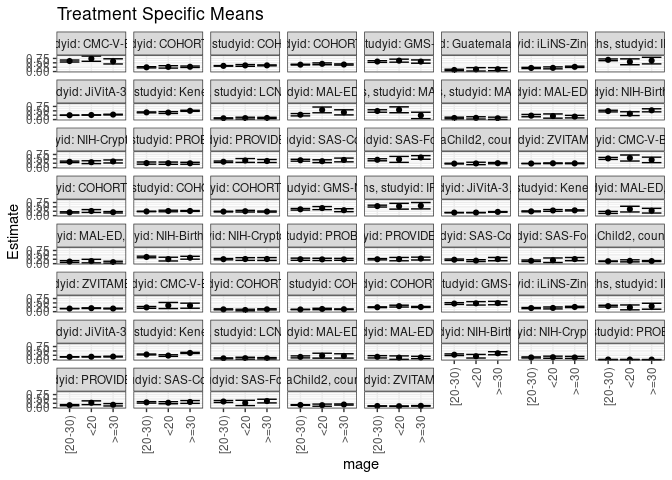

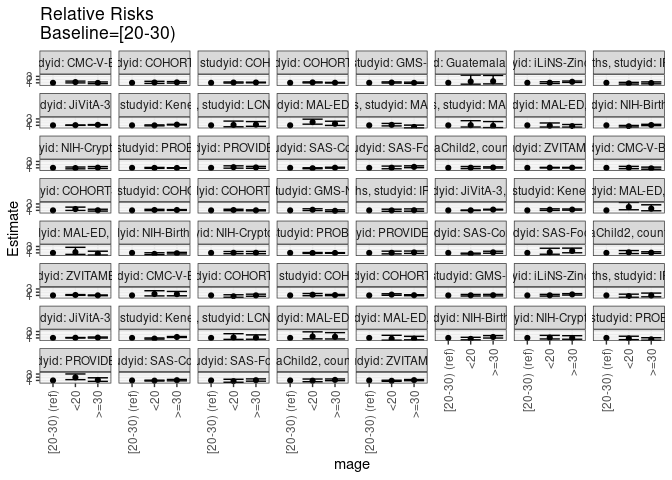

[figure not shown]

[figure not shown]

## Results Table

### Parameter: TSM

| agecat | studyid | country | intervention_level | baseline_level | estimate | ci_lower | ci_upper |
| --- | --- | --- | --- | --- | --- | --- | --- |
| 0-24 months | CMC-V-BCS-2002 | INDIA | [20-30) | NA | 0.6013514 | 0.5454986 | 0.6572041 |
| 0-24 months | CMC-V-BCS-2002 | INDIA | <20 | NA | 0.7352941 | 0.5868018 | 0.8837864 |
| 0-24 months | CMC-V-BCS-2002 | INDIA | >=30 | NA | 0.5813953 | 0.4337450 | 0.7290457 |
| 0-24 months | COHORTS | GUATEMALA | [20-30) | NA | 0.2432727 | 0.2093567 | 0.2771886 |
| 0-24 months | COHORTS | GUATEMALA | <20 | NA | 0.2666704 | 0.1974223 | 0.3359185 |
| 0-24 months | COHORTS | GUATEMALA | >=30 | NA | 0.2743458 | 0.2315020 | 0.3171896 |
| 0-24 months | COHORTS | INDIA | [20-30) | NA | 0.3251740 | 0.3096793 | 0.3406686 |
| 0-24 months | COHORTS | INDIA | <20 | NA | 0.3516127 | 0.3030638 | 0.4001615 |
| 0-24 months | COHORTS | INDIA | >=30 | NA | 0.3547805 | 0.3276432 | 0.3819178 |
| 0-24 months | COHORTS | PHILIPPINES | [20-30) | NA | 0.3944519 | 0.3717714 | 0.4171325 |
| 0-24 months | COHORTS | PHILIPPINES | <20 | NA | 0.4413199 | 0.3897813 | 0.4928585 |
| 0-24 months | COHORTS | PHILIPPINES | >=30 | NA | 0.4029021 | 0.3697517 | 0.4360525 |
| 0-24 months | GMS-Nepal | NEPAL | [20-30) | NA | 0.5724529 | 0.5258854 | 0.6190204 |
| 0-24 months | GMS-Nepal | NEPAL | <20 | NA | 0.6221346 | 0.5377213 | 0.7065479 |
| 0-24 months | GMS-Nepal | NEPAL | >=30 | NA | 0.5706283 | 0.4777452 | 0.6635114 |
| 0-24 months | Guatemala BSC | GUATEMALA | [20-30) | NA | 0.0914286 | 0.0486503 | 0.1342069 |
| 0-24 months | Guatemala BSC | GUATEMALA | <20 | NA | 0.1276596 | 0.0320849 | 0.2232343 |
| 0-24 months | Guatemala BSC | GUATEMALA | >=30 | NA | 0.1355932 | 0.0480799 | 0.2231066 |
| 0-24 months | iLiNS-Zinc | BURKINA FASO | [20-30) | NA | 0.2057700 | 0.1732475 | 0.2382925 |
| 0-24 months | iLiNS-Zinc | BURKINA FASO | <20 | NA | 0.2110457 | 0.1566325 | 0.2654590 |
| 0-24 months | iLiNS-Zinc | BURKINA FASO | >=30 | NA | 0.2705435 | 0.2343881 | 0.3066989 |
| 0-24 months | IRC | INDIA | [20-30) | NA | 0.6692416 | 0.6193466 | 0.7191365 |
| 0-24 months | IRC | INDIA | <20 | NA | 0.5574111 | 0.3898979 | 0.7249243 |
| 0-24 months | IRC | INDIA | >=30 | NA | 0.6269630 | 0.4389156 | 0.8150104 |
| 0-24 months | JiVitA-3 | BANGLADESH | [20-30) | NA | 0.2500215 | 0.2409273 | 0.2591157 |
| 0-24 months | JiVitA-3 | BANGLADESH | <20 | NA | 0.2620801 | 0.2524883 | 0.2716719 |
| 0-24 months | JiVitA-3 | BANGLADESH | >=30 | NA | 0.2858396 | 0.2646127 | 0.3070666 |
| 0-24 months | Keneba | GAMBIA | [20-30) | NA | 0.4122854 | 0.3864095 | 0.4381614 |
| 0-24 months | Keneba | GAMBIA | <20 | NA | 0.4032303 | 0.3521440 | 0.4543166 |
| 0-24 months | Keneba | GAMBIA | >=30 | NA | 0.5003202 | 0.4692987 | 0.5313417 |

[output cut: 153 more lines]

### Parameter: E(Y)

| agecat | studyid | country | intervention_level | baseline_level | estimate | ci_lower | ci_upper |
| --- | --- | --- | --- | --- | --- | --- | --- |
| 0-24 months | CMC-V-BCS-2002 | INDIA | NA | NA | 0.6112601 | 0.5617242 | 0.6607959 |
| 0-24 months | COHORTS | GUATEMALA | NA | NA | 0.2550336 | 0.2316956 | 0.2783715 |
| 0-24 months | COHORTS | INDIA | NA | NA | 0.3359095 | 0.3231988 | 0.3486203 |
| 0-24 months | COHORTS | PHILIPPINES | NA | NA | 0.4036125 | 0.3861835 | 0.4210415 |
| 0-24 months | GMS-Nepal | NEPAL | NA | NA | 0.5903790 | 0.5535526 | 0.6272054 |
| 0-24 months | Guatemala BSC | GUATEMALA | NA | NA | 0.1067616 | 0.0705906 | 0.1429325 |
| 0-24 months | iLiNS-Zinc | BURKINA FASO | NA | NA | 0.2274300 | 0.2005343 | 0.2543257 |
| 0-24 months | IRC | INDIA | NA | NA | 0.6560976 | 0.6100625 | 0.7021326 |
| 0-24 months | JiVitA-3 | BANGLADESH | NA | NA | 0.2580813 | 0.2516131 | 0.2645495 |
| 0-24 months | Keneba | GAMBIA | NA | NA | 0.4437849 | 0.4255860 | 0.4619838 |
| 0-24 months | LCNI-5 | MALAWI | NA | NA | 0.0805970 | 0.0599695 | 0.1012246 |
| 0-24 months | MAL-ED | BANGLADESH | NA | NA | 0.3307985 | 0.2738270 | 0.3877700 |
| 0-24 months | MAL-ED | INDIA | NA | NA | 0.4779116 | 0.4157435 | 0.5400798 |
| 0-24 months | MAL-ED | PERU | NA | NA | 0.0894040 | 0.0571706 | 0.1216374 |
| 0-24 months | MAL-ED | SOUTH AFRICA | NA | NA | 0.2051282 | 0.1602507 | 0.2500058 |
| 0-24 months | NIH-Birth | BANGLADESH | NA | NA | 0.4774920 | 0.4382065 | 0.5167774 |
| 0-24 months | NIH-Crypto | BANGLADESH | NA | NA | 0.3298153 | 0.2963239 | 0.3633067 |
| 0-24 months | PROBIT | BELARUS | NA | NA | 0.2554148 | 0.1971257 | 0.3137039 |
| 0-24 months | PROVIDE | BANGLADESH | NA | NA | 0.3514286 | 0.3160364 | 0.3868207 |
| 0-24 months | SAS-CompFeed | INDIA | NA | NA | 0.4150694 | 0.3581204 | 0.4720184 |
| 0-24 months | SAS-FoodSuppl | INDIA | NA | NA | 0.4712919 | 0.4233811 | 0.5192026 |
| 0-24 months | TanzaniaChild2 | TANZANIA, UNITED REPUBLIC OF | NA | NA | 0.2369529 | 0.2198518 | 0.2540539 |
| 0-24 months | ZVITAMBO | ZIMBABWE | NA | NA | 0.2365545 | 0.2294916 | 0.2436174 |
| 0-6 months | CMC-V-BCS-2002 | INDIA | NA | NA | 0.5163043 | 0.4651769 | 0.5674318 |
| 0-6 months | COHORTS | GUATEMALA | NA | NA | 0.2003763 | 0.1763021 | 0.2244505 |
| 0-6 months | COHORTS | INDIA | NA | NA | 0.2500980 | 0.2382136 | 0.2619824 |
| 0-6 months | COHORTS | PHILIPPINES | NA | NA | 0.2355453 | 0.2204685 | 0.2506222 |
| 0-6 months | GMS-Nepal | NEPAL | NA | NA | 0.3760933 | 0.3398180 | 0.4123685 |
| 0-6 months | IRC | INDIA | NA | NA | 0.5439024 | 0.4956326 | 0.5921723 |
| 0-6 months | JiVitA-3 | BANGLADESH | NA | NA | 0.1762142 | 0.1705882 | 0.1818403 |
| 0-6 months | Keneba | GAMBIA | NA | NA | 0.2749591 | 0.2572539 | 0.2926643 |
| 0-6 months | MAL-ED | BANGLADESH | NA | NA | 0.2281369 | 0.1773250 | 0.2789488 |
| 0-6 months | MAL-ED | SOUTH AFRICA | NA | NA | 0.1121795 | 0.0771053 | 0.1472536 |
| 0-6 months | NIH-Birth | BANGLADESH | NA | NA | 0.3580645 | 0.3202961 | 0.3958330 |
| 0-6 months | NIH-Crypto | BANGLADESH | NA | NA | 0.2572559 | 0.2261171 | 0.2883948 |
| 0-6 months | PROBIT | BELARUS | NA | NA | 0.2500148 | 0.1915461 | 0.3084835 |
| 0-6 months | PROVIDE | BANGLADESH | NA | NA | 0.2585714 | 0.2261125 | 0.2910304 |
| 0-6 months | SAS-CompFeed | INDIA | NA | NA | 0.2199336 | 0.1753445 | 0.2645227 |
| 0-6 months | SAS-FoodSuppl | INDIA | NA | NA | 0.1866029 | 0.1492099 | 0.2239959 |
| 0-6 months | TanzaniaChild2 | TANZANIA, UNITED REPUBLIC OF | NA | NA | 0.1397306 | 0.1257869 | 0.1536744 |
| 0-6 months | ZVITAMBO | ZIMBABWE | NA | NA | 0.1808903 | 0.1744713 | 0.1873093 |
| 6-24 months | CMC-V-BCS-2002 | INDIA | NA | NA | 0.2654155 | 0.2205451 | 0.3102860 |
| 6-24 months | COHORTS | GUATEMALA | NA | NA | 0.1269580 | 0.1082147 | 0.1457012 |
| 6-24 months | COHORTS | INDIA | NA | NA | 0.1317329 | 0.1223171 | 0.1411487 |
| 6-24 months | COHORTS | PHILIPPINES | NA | NA | 0.2666429 | 0.2502871 | 0.2829988 |
| 6-24 months | GMS-Nepal | NEPAL | NA | NA | 0.4728814 | 0.4325613 | 0.5132014 |
| 6-24 months | iLiNS-Zinc | BURKINA FASO | NA | NA | 0.2274300 | 0.2005343 | 0.2543257 |
| 6-24 months | IRC | INDIA | NA | NA | 0.3097561 | 0.2649438 | 0.3545684 |
| 6-24 months | JiVitA-3 | BANGLADESH | NA | NA | 0.1640643 | 0.1579507 | 0.1701779 |
| 6-24 months | Keneba | GAMBIA | NA | NA | 0.3201934 | 0.3025561 | 0.3378307 |
| 6-24 months | LCNI-5 | MALAWI | NA | NA | 0.0789074 | 0.0583085 | 0.0995064 |
| 6-24 months | MAL-ED | BANGLADESH | NA | NA | 0.1791667 | 0.1305478 | 0.2277856 |
| 6-24 months | MAL-ED | SOUTH AFRICA | NA | NA | 0.1428571 | 0.1001583 | 0.1855560 |
| 6-24 months | NIH-Birth | BANGLADESH | NA | NA | 0.2925926 | 0.2541847 | 0.3310005 |
| 6-24 months | NIH-Crypto | BANGLADESH | NA | NA | 0.1315068 | 0.1069744 | 0.1560393 |
| 6-24 months | PROBIT | BELARUS | NA | NA | 0.0083745 | 0.0044130 | 0.0123360 |
| 6-24 months | PROVIDE | BANGLADESH | NA | NA | 0.1609756 | 0.1319065 | 0.1900447 |
| 6-24 months | SAS-CompFeed | INDIA | NA | NA | 0.3059755 | 0.2638053 | 0.3481458 |
| 6-24 months | SAS-FoodSuppl | INDIA | NA | NA | 0.3557214 | 0.3088651 | 0.4025777 |
| 6-24 months | TanzaniaChild2 | TANZANIA, UNITED REPUBLIC OF | NA | NA | 0.1607589 | 0.1446692 | 0.1768485 |
| 6-24 months | ZVITAMBO | ZIMBABWE | NA | NA | 0.0959310 | 0.0903738 | 0.1014883 |

### Parameter: RR

| agecat | studyid | country | intervention_level | baseline_level | estimate | ci_lower | ci_upper |
| --- | --- | --- | --- | --- | --- | --- | --- |
| 0-24 months | CMC-V-BCS-2002 | INDIA | [20-30) | [20-30) | 1.0000000 | 1.0000000 | 1.0000000 |
| 0-24 months | CMC-V-BCS-2002 | INDIA | <20 | [20-30) | 1.2227363 | 0.9790304 | 1.5271068 |
| 0-24 months | CMC-V-BCS-2002 | INDIA | >=30 | [20-30) | 0.9668147 | 0.7377441 | 1.2670121 |
| 0-24 months | COHORTS | GUATEMALA | [20-30) | [20-30) | 1.0000000 | 1.0000000 | 1.0000000 |
| 0-24 months | COHORTS | GUATEMALA | <20 | [20-30) | 1.0961791 | 0.8173695 | 1.4700923 |
| 0-24 months | COHORTS | GUATEMALA | >=30 | [20-30) | 1.1277297 | 0.9157967 | 1.3887082 |
| 0-24 months | COHORTS | INDIA | [20-30) | [20-30) | 1.0000000 | 1.0000000 | 1.0000000 |
| 0-24 months | COHORTS | INDIA | <20 | [20-30) | 1.0813064 | 0.9344350 | 1.2512626 |
| 0-24 months | COHORTS | INDIA | >=30 | [20-30) | 1.0910482 | 0.9972021 | 1.1937261 |
| 0-24 months | COHORTS | PHILIPPINES | [20-30) | [20-30) | 1.0000000 | 1.0000000 | 1.0000000 |
| 0-24 months | COHORTS | PHILIPPINES | <20 | [20-30) | 1.1188180 | 0.9823019 | 1.2743064 |
| 0-24 months | COHORTS | PHILIPPINES | >=30 | [20-30) | 1.0214226 | 0.9239078 | 1.1292297 |
| 0-24 months | GMS-Nepal | NEPAL | [20-30) | [20-30) | 1.0000000 | 1.0000000 | 1.0000000 |
| 0-24 months | GMS-Nepal | NEPAL | <20 | [20-30) | 1.0867874 | 0.9276080 | 1.2732823 |
| 0-24 months | GMS-Nepal | NEPAL | >=30 | [20-30) | 0.9968126 | 0.8310212 | 1.1956800 |
| 0-24 months | Guatemala BSC | GUATEMALA | [20-30) | [20-30) | 1.0000000 | 1.0000000 | 1.0000000 |
| 0-24 months | Guatemala BSC | GUATEMALA | <20 | [20-30) | 1.3962766 | 0.5775036 | 3.3758896 |
| 0-24 months | Guatemala BSC | GUATEMALA | >=30 | [20-30) | 1.4830508 | 0.6682686 | 3.2912512 |
| 0-24 months | iLiNS-Zinc | BURKINA FASO | [20-30) | [20-30) | 1.0000000 | 1.0000000 | 1.0000000 |
| 0-24 months | iLiNS-Zinc | BURKINA FASO | <20 | [20-30) | 1.0256389 | 0.7914523 | 1.3291202 |
| 0-24 months | iLiNS-Zinc | BURKINA FASO | >=30 | [20-30) | 1.3147858 | 1.1144002 | 1.5512036 |
| 0-24 months | IRC | INDIA | [20-30) | [20-30) | 1.0000000 | 1.0000000 | 1.0000000 |
| 0-24 months | IRC | INDIA | <20 | [20-30) | 0.8328997 | 0.6110200 | 1.1353505 |
| 0-24 months | IRC | INDIA | >=30 | [20-30) | 0.9368261 | 0.6877361 | 1.2761336 |
| 0-24 months | JiVitA-3 | BANGLADESH | [20-30) | [20-30) | 1.0000000 | 1.0000000 | 1.0000000 |
| 0-24 months | JiVitA-3 | BANGLADESH | <20 | [20-30) | 1.0482303 | 0.9992858 | 1.0995721 |
| 0-24 months | JiVitA-3 | BANGLADESH | >=30 | [20-30) | 1.1432602 | 1.0552094 | 1.2386582 |
| 0-24 months | Keneba | GAMBIA | [20-30) | [20-30) | 1.0000000 | 1.0000000 | 1.0000000 |
| 0-24 months | Keneba | GAMBIA | <20 | [20-30) | 0.9780366 | 0.8490638 | 1.1266004 |
| 0-24 months | Keneba | GAMBIA | >=30 | [20-30) | 1.2135286 | 1.1114340 | 1.3250015 |

[output cut: 153 more lines]

### Parameter: PAR

| agecat | studyid | country | intervention_level | baseline_level | estimate | ci_lower | ci_upper |
| --- | --- | --- | --- | --- | --- | --- | --- |
| 0-24 months | CMC-V-BCS-2002 | INDIA | [20-30) | NA | 0.0099087 | -0.0150357 | 0.0348531 |
| 0-24 months | COHORTS | GUATEMALA | [20-30) | NA | 0.0117609 | -0.0132059 | 0.0367277 |
| 0-24 months | COHORTS | INDIA | [20-30) | NA | 0.0107356 | 0.0015827 | 0.0198884 |
| 0-24 months | COHORTS | PHILIPPINES | [20-30) | NA | 0.0091605 | -0.0054102 | 0.0237313 |
| 0-24 months | GMS-Nepal | NEPAL | [20-30) | NA | 0.0179261 | -0.0095910 | 0.0454432 |
| 0-24 months | Guatemala BSC | GUATEMALA | [20-30) | NA | 0.0153330 | -0.0139754 | 0.0446414 |
| 0-24 months | iLiNS-Zinc | BURKINA FASO | [20-30) | NA | 0.0216600 | 0.0067336 | 0.0365864 |
| 0-24 months | IRC | INDIA | [20-30) | NA | -0.0131440 | -0.0341856 | 0.0078975 |
| 0-24 months | JiVitA-3 | BANGLADESH | [20-30) | NA | 0.0080598 | 0.0017744 | 0.0143452 |
| 0-24 months | Keneba | GAMBIA | [20-30) | NA | 0.0314995 | 0.0129464 | 0.0500526 |
| 0-24 months | LCNI-5 | MALAWI | [20-30) | NA | 0.0064212 | -0.0126225 | 0.0254649 |
| 0-24 months | MAL-ED | BANGLADESH | [20-30) | NA | 0.0533146 | 0.0128239 | 0.0938054 |
| 0-24 months | MAL-ED | INDIA | [20-30) | NA | -0.0117791 | -0.0448166 | 0.0212585 |
| 0-24 months | MAL-ED | PERU | [20-30) | NA | -0.0020993 | -0.0338995 | 0.0297009 |
| 0-24 months | MAL-ED | SOUTH AFRICA | [20-30) | NA | -0.0211605 | -0.0654283 | 0.0231073 |
| 0-24 months | NIH-Birth | BANGLADESH | [20-30) | NA | -0.0090625 | -0.0366667 | 0.0185418 |
| 0-24 months | NIH-Crypto | BANGLADESH | [20-30) | NA | -0.0013608 | -0.0259648 | 0.0232431 |
| 0-24 months | PROBIT | BELARUS | [20-30) | NA | -0.0029624 | -0.0093730 | 0.0034482 |
| 0-24 months | PROVIDE | BANGLADESH | [20-30) | NA | 0.0163066 | -0.0068805 | 0.0394937 |
| 0-24 months | SAS-CompFeed | INDIA | [20-30) | NA | -0.0048125 | -0.0140309 | 0.0044059 |
| 0-24 months | SAS-FoodSuppl | INDIA | [20-30) | NA | 0.0248858 | -0.0071505 | 0.0569220 |
| 0-24 months | TanzaniaChild2 | TANZANIA, UNITED REPUBLIC OF | [20-30) | NA | 0.0074126 | -0.0049762 | 0.0198013 |
| 0-24 months | ZVITAMBO | ZIMBABWE | [20-30) | NA | 0.0024932 | -0.0031061 | 0.0080924 |
| 0-6 months | CMC-V-BCS-2002 | INDIA | [20-30) | NA | -0.0067548 | -0.0330803 | 0.0195707 |
| 0-6 months | COHORTS | GUATEMALA | [20-30) | NA | 0.0131077 | -0.0119542 | 0.0381695 |
| 0-6 months | COHORTS | INDIA | [20-30) | NA | 0.0110353 | 0.0024323 | 0.0196382 |
| 0-6 months | COHORTS | PHILIPPINES | [20-30) | NA | 0.0055654 | -0.0070405 | 0.0181714 |
| 0-6 months | GMS-Nepal | NEPAL | [20-30) | NA | 0.0145653 | -0.0126366 | 0.0417672 |
| 0-6 months | IRC | INDIA | [20-30) | NA | 0.0002436 | -0.0210260 | 0.0215131 |
| 0-6 months | JiVitA-3 | BANGLADESH | [20-30) | NA | 0.0034297 | -0.0021824 | 0.0090418 |
| 0-6 months | Keneba | GAMBIA | [20-30) | NA | 0.0312506 | 0.0123746 | 0.0501265 |
| 0-6 months | MAL-ED | BANGLADESH | [20-30) | NA | 0.0454788 | 0.0079339 | 0.0830237 |
| 0-6 months | MAL-ED | SOUTH AFRICA | [20-30) | NA | -0.0073174 | -0.0416853 | 0.0270505 |
| 0-6 months | NIH-Birth | BANGLADESH | [20-30) | NA | -0.0235554 | -0.0496072 | 0.0024964 |
| 0-6 months | NIH-Crypto | BANGLADESH | [20-30) | NA | 0.0014323 | -0.0215090 | 0.0243736 |
| 0-6 months | PROBIT | BELARUS | [20-30) | NA | -0.0029062 | -0.0094282 | 0.0036158 |
| 0-6 months | PROVIDE | BANGLADESH | [20-30) | NA | 0.0063098 | -0.0150288 | 0.0276484 |
| 0-6 months | SAS-CompFeed | INDIA | [20-30) | NA | -0.0044653 | -0.0143501 | 0.0054195 |
| 0-6 months | SAS-FoodSuppl | INDIA | [20-30) | NA | 0.0245339 | -0.0019120 | 0.0509798 |
| 0-6 months | TanzaniaChild2 | TANZANIA, UNITED REPUBLIC OF | [20-30) | NA | 0.0024049 | -0.0076630 | 0.0124728 |
| 0-6 months | ZVITAMBO | ZIMBABWE | [20-30) | NA | 0.0037892 | -0.0010446 | 0.0086229 |
| 6-24 months | CMC-V-BCS-2002 | INDIA | [20-30) | NA | 0.0218567 | -0.0027427 | 0.0464560 |
| 6-24 months | COHORTS | GUATEMALA | [20-30) | NA | -0.0055301 | -0.0248808 | 0.0138206 |
| 6-24 months | COHORTS | INDIA | [20-30) | NA | 0.0051503 | -0.0019596 | 0.0122601 |
| 6-24 months | COHORTS | PHILIPPINES | [20-30) | NA | 0.0129120 | -0.0010892 | 0.0269132 |
| 6-24 months | GMS-Nepal | NEPAL | [20-30) | NA | 0.0103562 | -0.0198232 | 0.0405355 |
| 6-24 months | iLiNS-Zinc | BURKINA FASO | [20-30) | NA | 0.0211504 | 0.0060564 | 0.0362443 |
| 6-24 months | IRC | INDIA | [20-30) | NA | -0.0071044 | -0.0262133 | 0.0120045 |
| 6-24 months | JiVitA-3 | BANGLADESH | [20-30) | NA | 0.0035353 | -0.0033272 | 0.0103978 |
| 6-24 months | Keneba | GAMBIA | [20-30) | NA | 0.0215716 | 0.0033091 | 0.0398342 |
| 6-24 months | LCNI-5 | MALAWI | [20-30) | NA | 0.0032772 | -0.0157344 | 0.0222887 |
| 6-24 months | MAL-ED | BANGLADESH | [20-30) | NA | 0.0196575 | -0.0153694 | 0.0546844 |
| 6-24 months | MAL-ED | SOUTH AFRICA | [20-30) | NA | -0.0210773 | -0.0666196 | 0.0244650 |
| 6-24 months | NIH-Birth | BANGLADESH | [20-30) | NA | 0.0082321 | -0.0189913 | 0.0354555 |
| 6-24 months | NIH-Crypto | BANGLADESH | [20-30) | NA | 0.0036420 | -0.0145675 | 0.0218515 |
| 6-24 months | PROBIT | BELARUS | [20-30) | NA | -0.0007572 | -0.0016955 | 0.0001810 |
| 6-24 months | PROVIDE | BANGLADESH | [20-30) | NA | 0.0148069 | -0.0050152 | 0.0346291 |
| 6-24 months | SAS-CompFeed | INDIA | [20-30) | NA | 0.0007476 | -0.0085794 | 0.0100746 |
| 6-24 months | SAS-FoodSuppl | INDIA | [20-30) | NA | 0.0015318 | -0.0297017 | 0.0327653 |
| 6-24 months | TanzaniaChild2 | TANZANIA, UNITED REPUBLIC OF | [20-30) | NA | 0.0048123 | -0.0071796 | 0.0168043 |
| 6-24 months | ZVITAMBO | ZIMBABWE | [20-30) | NA | -0.0012091 | -0.0057730 | 0.0033548 |

### Parameter: PAF

| agecat | studyid | country | intervention_level | baseline_level | estimate | ci_lower | ci_upper |
| --- | --- | --- | --- | --- | --- | --- | --- |
| 0-24 months | CMC-V-BCS-2002 | INDIA | [20-30) | NA | 0.0162103 | -0.0255022 | 0.0562261 |
| 0-24 months | COHORTS | GUATEMALA | [20-30) | NA | 0.0461151 | -0.0570106 | 0.1391795 |
| 0-24 months | COHORTS | INDIA | [20-30) | NA | 0.0319597 | 0.0043252 | 0.0588272 |
| 0-24 months | COHORTS | PHILIPPINES | [20-30) | NA | 0.0226964 | -0.0140899 | 0.0581483 |
| 0-24 months | GMS-Nepal | NEPAL | [20-30) | NA | 0.0303637 | -0.0174783 | 0.0759562 |
| 0-24 months | Guatemala BSC | GUATEMALA | [20-30) | NA | 0.1436190 | -0.1752619 | 0.3759788 |
| 0-24 months | iLiNS-Zinc | BURKINA FASO | [20-30) | NA | 0.0952381 | 0.0244939 | 0.1608519 |
| 0-24 months | IRC | INDIA | [20-30) | NA | -0.0200336 | -0.0526998 | 0.0116189 |
| 0-24 months | JiVitA-3 | BANGLADESH | [20-30) | NA | 0.0312297 | 0.0065403 | 0.0553054 |
| 0-24 months | Keneba | GAMBIA | [20-30) | NA | 0.0709791 | 0.0281381 | 0.1119316 |
| 0-24 months | LCNI-5 | MALAWI | [20-30) | NA | 0.0796703 | -0.1887603 | 0.2874874 |
| 0-24 months | MAL-ED | BANGLADESH | [20-30) | NA | 0.1611695 | 0.0299050 | 0.2746725 |
| 0-24 months | MAL-ED | INDIA | [20-30) | NA | -0.0246470 | -0.0962308 | 0.0422625 |
| 0-24 months | MAL-ED | PERU | [20-30) | NA | -0.0234810 | -0.4486935 | 0.2769255 |
| 0-24 months | MAL-ED | SOUTH AFRICA | [20-30) | NA | -0.1031573 | -0.3407043 | 0.0923009 |
| 0-24 months | NIH-Birth | BANGLADESH | [20-30) | NA | -0.0189793 | -0.0784901 | 0.0372477 |
| 0-24 months | NIH-Crypto | BANGLADESH | [20-30) | NA | -0.0041261 | -0.0815641 | 0.0677676 |
| 0-24 months | PROBIT | BELARUS | [20-30) | NA | -0.0115984 | -0.0359223 | 0.0121544 |
| 0-24 months | PROVIDE | BANGLADESH | [20-30) | NA | 0.0464008 | -0.0218812 | 0.1101203 |
| 0-24 months | SAS-CompFeed | INDIA | [20-30) | NA | -0.0115945 | -0.0348642 | 0.0111520 |
| 0-24 months | SAS-FoodSuppl | INDIA | [20-30) | NA | 0.0528033 | -0.0178317 | 0.1185364 |
| 0-24 months | TanzaniaChild2 | TANZANIA, UNITED REPUBLIC OF | [20-30) | NA | 0.0312828 | -0.0224388 | 0.0821818 |
| 0-24 months | ZVITAMBO | ZIMBABWE | [20-30) | NA | 0.0105395 | -0.0134176 | 0.0339302 |
| 0-6 months | CMC-V-BCS-2002 | INDIA | [20-30) | NA | -0.0130829 | -0.0653924 | 0.0366582 |
| 0-6 months | COHORTS | GUATEMALA | [20-30) | NA | 0.0654153 | -0.0682664 | 0.1823682 |
| 0-6 months | COHORTS | INDIA | [20-30) | NA | 0.0441237 | 0.0091185 | 0.0778923 |
| 0-6 months | COHORTS | PHILIPPINES | [20-30) | NA | 0.0236279 | -0.0313789 | 0.0757010 |
| 0-6 months | GMS-Nepal | NEPAL | [20-30) | NA | 0.0387280 | -0.0364430 | 0.1084470 |
| 0-6 months | IRC | INDIA | [20-30) | NA | 0.0004478 | -0.0394327 | 0.0387983 |
| 0-6 months | JiVitA-3 | BANGLADESH | [20-30) | NA | 0.0194633 | -0.0129270 | 0.0508178 |
| 0-6 months | Keneba | GAMBIA | [20-30) | NA | 0.1136553 | 0.0423159 | 0.1796804 |
| 0-6 months | MAL-ED | BANGLADESH | [20-30) | NA | 0.1993488 | 0.0202252 | 0.3457247 |
| 0-6 months | MAL-ED | SOUTH AFRICA | [20-30) | NA | -0.0652291 | -0.4195344 | 0.2006442 |
| 0-6 months | NIH-Birth | BANGLADESH | [20-30) | NA | -0.0657853 | -0.1411581 | 0.0046091 |
| 0-6 months | NIH-Crypto | BANGLADESH | [20-30) | NA | 0.0055677 | -0.0877281 | 0.0908614 |
| 0-6 months | PROBIT | BELARUS | [20-30) | NA | -0.0116242 | -0.0369234 | 0.0130576 |
| 0-6 months | PROVIDE | BANGLADESH | [20-30) | NA | 0.0244025 | -0.0616757 | 0.1035016 |
| 0-6 months | SAS-CompFeed | INDIA | [20-30) | NA | -0.0203030 | -0.0693779 | 0.0265199 |
| 0-6 months | SAS-FoodSuppl | INDIA | [20-30) | NA | 0.1314766 | -0.0207230 | 0.2609817 |
| 0-6 months | TanzaniaChild2 | TANZANIA, UNITED REPUBLIC OF | [20-30) | NA | 0.0172110 | -0.0575498 | 0.0866867 |
| 0-6 months | ZVITAMBO | ZIMBABWE | [20-30) | NA | 0.0209474 | -0.0061422 | 0.0473076 |
| 6-24 months | CMC-V-BCS-2002 | INDIA | [20-30) | NA | 0.0823489 | -0.0148756 | 0.1702594 |
| 6-24 months | COHORTS | GUATEMALA | [20-30) | NA | -0.0435586 | -0.2074850 | 0.0981134 |
| 6-24 months | COHORTS | INDIA | [20-30) | NA | 0.0390963 | -0.0163454 | 0.0915136 |
| 6-24 months | COHORTS | PHILIPPINES | [20-30) | NA | 0.0484243 | -0.0055479 | 0.0994996 |
| 6-24 months | GMS-Nepal | NEPAL | [20-30) | NA | 0.0219001 | -0.0441101 | 0.0837371 |
| 6-24 months | iLiNS-Zinc | BURKINA FASO | [20-30) | NA | 0.0929972 | 0.0215124 | 0.1592596 |
| 6-24 months | IRC | INDIA | [20-30) | NA | -0.0229354 | -0.0865158 | 0.0369245 |
| 6-24 months | JiVitA-3 | BANGLADESH | [20-30) | NA | 0.0215483 | -0.0211672 | 0.0624770 |
| 6-24 months | Keneba | GAMBIA | [20-30) | NA | 0.0673707 | 0.0085267 | 0.1227223 |
| 6-24 months | LCNI-5 | MALAWI | [20-30) | NA | 0.0415320 | -0.2321283 | 0.2544113 |
| 6-24 months | MAL-ED | BANGLADESH | [20-30) | NA | 0.1097161 | -0.1071782 | 0.2841211 |
| 6-24 months | MAL-ED | SOUTH AFRICA | [20-30) | NA | -0.1475410 | -0.5125291 | 0.1293719 |
| 6-24 months | NIH-Birth | BANGLADESH | [20-30) | NA | 0.0281350 | -0.0694815 | 0.1168416 |
| 6-24 months | NIH-Crypto | BANGLADESH | [20-30) | NA | 0.0276943 | -0.1210823 | 0.1567271 |
| 6-24 months | PROBIT | BELARUS | [20-30) | NA | -0.0904230 | -0.1914142 | 0.0020075 |
| 6-24 months | PROVIDE | BANGLADESH | [20-30) | NA | 0.0919826 | -0.0388033 | 0.2063024 |
| 6-24 months | SAS-CompFeed | INDIA | [20-30) | NA | 0.0024433 | -0.0284194 | 0.0323797 |
| 6-24 months | SAS-FoodSuppl | INDIA | [20-30) | NA | 0.0043061 | -0.0874869 | 0.0883510 |
| 6-24 months | TanzaniaChild2 | TANZANIA, UNITED REPUBLIC OF | [20-30) | NA | 0.0299350 | -0.0476077 | 0.1017381 |
| 6-24 months | ZVITAMBO | ZIMBABWE | [20-30) | NA | -0.0126040 | -0.0613025 | 0.0338600 |